# Question

For each of the patterns below, determine the Frieze group.

## Pattern 1

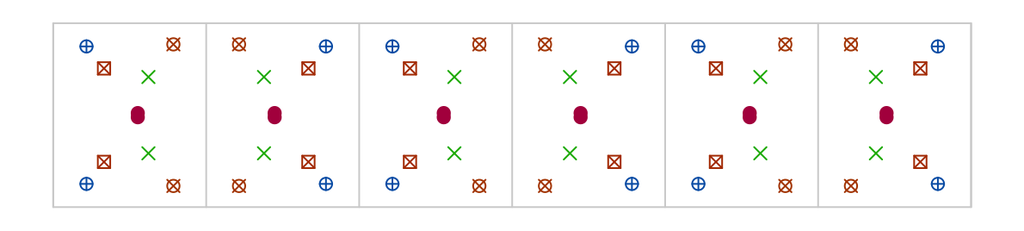

Frieze group: ##ANSWER1##

## Pattern 2

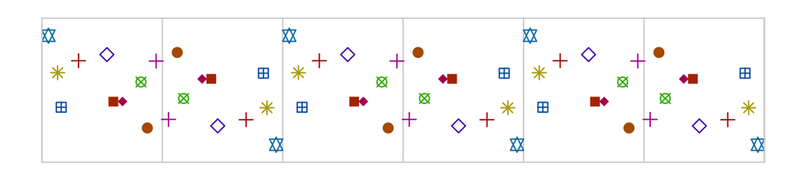

Frieze group: ##ANSWER2##

## Pattern 3

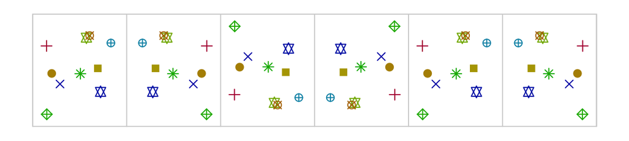

Frieze group: ##ANSWER3##

## Pattern 4

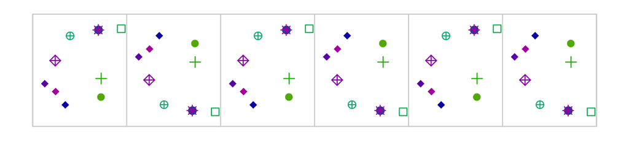

Frieze group: ##ANSWER4##

## Pattern 5

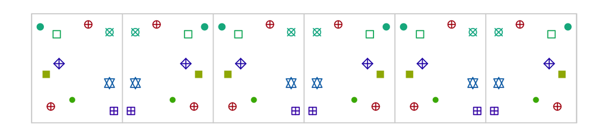

Frieze group: ##ANSWER5##

## Pattern 6

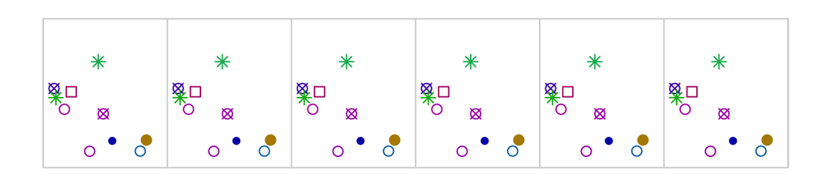

Frieze group: ##ANSWER6##

## Pattern 7

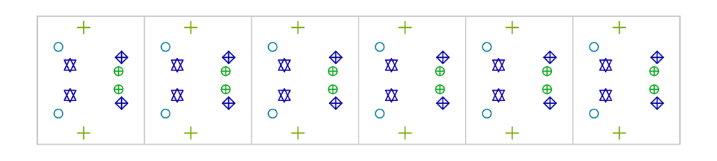

Frieze group: ##ANSWER7##

## Answerlist

- p1 (hop)
- p11g (step)
- p1m1 (sidle)
- p2 (spinning hop)
- p2mg (spinning sidle)
- p11m (jump)
- p2mm (spinning jump)
- p1 (hop)
- p11g (step)
- p1m1 (sidle)
- p2 (spinning hop)
- p2mg (spinning sidle)
- p11m (jump)
- p2mm (spinning jump)
- p1 (hop)
- p11g (step)
- p1m1 (sidle)
- p2 (spinning hop)
- p2mg (spinning sidle)
- p11m (jump)
- p2mm (spinning jump)
- p1 (hop)
- p11g (step)
- p1m1 (sidle)
- p2 (spinning hop)
- p2mg (spinning sidle)
- p11m (jump)
- p2mm (spinning jump)
- p1 (hop)
- p11g (step)
- p1m1 (sidle)
- p2 (spinning hop)
- p2mg (spinning sidle)
- p11m (jump)
- p2mm (spinning jump)
- p1 (hop)
- p11g (step)
- p1m1 (sidle)
- p2 (spinning hop)
- p2mg (spinning sidle)
- p11m (jump)
- p2mm (spinning jump)
- p1 (hop)
- p11g (step)
- p1m1 (sidle)
- p2 (spinning hop)
- p2mg (spinning sidle)
- p11m (jump)
- p2mm (spinning jump)

# Solution

- The first pattern is a p2mm (spinning jump).
- The second pattern is a p2 (spinning hop).
- The third pattern is a p2mg (spinning sidle).
- The fourth pattern is a p11g (step).
- The fifth pattern is a p1m1 (sidle).
- The sixth pattern is a p1 (hop).
- The seventh pattern is a p11m (jump).

# Meta-information

extype: cloze exclozetype: schoice|schoice|schoice|schoice|schoice|schoice|schoice exsolution: 0000001|0001000|0000100|0100000|0010000|1000000|0000010 exname: recognize_Frieze_group